# Introduction

Deep neural network models (including LLMs) generally can not process text directly because text data is categorial and therefore it isn't compatible with mathematical operations used to implement and train neural networks. This necessitates the need of representing words as *continous-valued* vectors. This concept of converting data into vector format is often refered to as **embedding**.

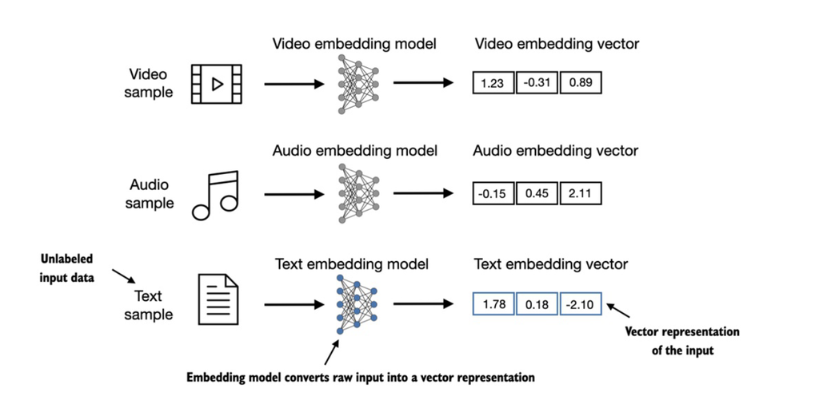

Through embedding models, we can process data of all types including video, audio, and text. Typically, different data types require different embedding models (*i.e.* the embedding model for audio would not be suitable for text data), but there are current research that try to design one embedding for all types of data (Girdhar et al., 2023).

# Word2Vec

## Word vectors

A dense vector for each word, chosen so that it is similar to vectors of words that appear in similar contexts. Word vectors are also called word embedding or word representations.

## Word2Vec Algorithm

There are several algorithms and frameworks that have been developed to generate word embeddings. The earliest and most popular method is *Word2Vec*, proposed by Mikolov et al., 2013. Word2Vec trained a neural network architecture to generate word embeddings by predicting the context of a word given the target word or vice versa. This approach is similar to the notion of *"You shall now a word by a company it keeps"*. The main idea behind Word2Vec is that words that appear in similar contexts tend to have similar meanings. For this reason, when projected into low dimensional word embeddings (2-3 for visualization purposes), we can see that similar terms cluster together. The higher the dimensionality, the more effective the model is in terms of capturing nuances word relationships but this comes with the cost of computation efficiency. For GPT-2 and GPT-3 models, the embedding size varied based on the specific model variant and size. The smaller GPT-2 models uses an embedding that has 768 dimensions, while the largest GPT-3 model uses an embedding size of 12228 dimensions.

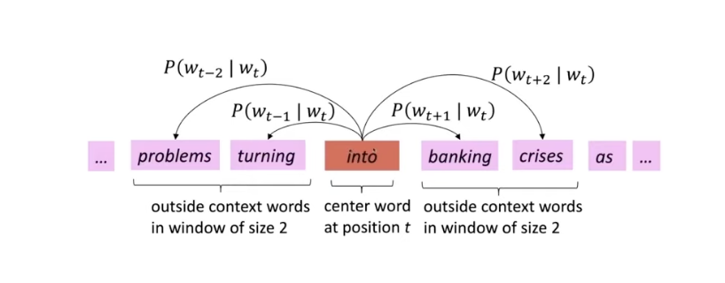

# References

Girdhar, R., El-Nouby, A., Liu, Z., Singh, M., Alwala, K. V., Joulin, A., & Misra, I. (2023). ImageBind One Embedding Space to Bind Them All. 2023 IEEE/CVF Conference on Computer Vision and Pattern Recognition (CVPR). https://doi.org/10.1109/cvpr52729.2023.01457

Mikolov, T., Chen, K., Corrado, G., & Dean, J. (2013). Efficient Estimation of Word Representations in Vector Space. International Conference on Learning Representations.